# ANÁLISIS DE SINIESTRALIDAD

### XGBoost con PCA

```
[19:26:03] WARNING: ../src/learner.cc:1115: Starting in XGBoost 1.3.0, the default evaluation metric used with the objective 'binary:logistic' was changed from 'error' to 'logloss'. Explicitly set eval_metric if you'd like to restore the old behavior.
```

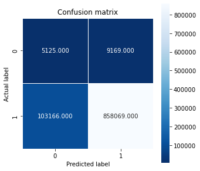

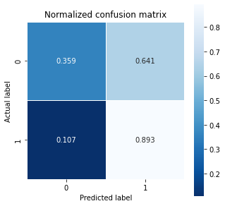

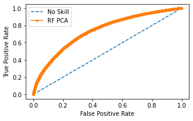

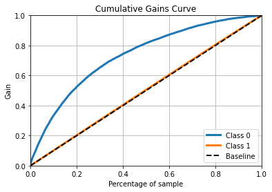

```python
start_XGB_PCA, final_XGB_PCA, prediction_XGB_PCA, predictions_proba_XGB_PCA, XGB_PCA= modelos(X_train_pca_2, y_train_oversampled, X_test_pca_2, XGBClassifier(), ytest)
```

La mtriz de confusión que se obtiene tiene una mejor forma que la que hemos obtenido antes al ejecutar el XGBoost sin PCA y sin el threshold de ROC. La mejor forma se debe a que acertamos más los fallecidos que antes. Sin embargo, introduzcamos el threshold de ROC para ver si el modelo puede llegar a superar al de RandomForest obtenido anteriormente.

##### THRESHOLD ÓPTIMO MEDIANTE LA CURVA DE ROC

```python
yhat_XGB_PCA = predictions_proba_XGB_PCA[:, 1]
fpr_XGB_PCA, tpr_XGB_PCA, thresholds_XGB_PCA = roc_curve(ytest, yhat_XGB_PCA)
```

```
Best Threshold=0.717283, F-Score=0.680
```

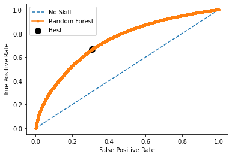

```python
gmeans_XGB_PCA = np.sqrt(tpr_XGB_PCA * (1-fpr_XGB_PCA))
ix_XGB_PCA = np.argmax(np.sqrt(tpr_XGB_PCA * (1-fpr_XGB_PCA)))
predictions_roc_XGB_PCA=(predictions_proba_XGB_PCA[:,1] >= thresholds_XGB_PCA[ix_XGB_PCA]).astype(int)
print('Best Threshold=%f, F-Score=%.3f' % (thresholds_XGB_PCA[ix_XGB_PCA], gmeans_XGB_PCA[ix_XGB_PCA]))

plt.plot([0,1], [0,1], linestyle='--', label='No Skill')
plt.plot(fpr_XGB_PCA, tpr_XGB_PCA, marker='.', label='Random Forest')
plt.scatter(fpr_XGB_PCA[ix_XGB_PCA], tpr_XGB_PCA[ix_XGB_PCA], s=100, marker='o', color='black', label='Best')
# axis labels
plt.xlabel('False Positive Rate')
plt.ylabel('True Positive Rate')
plt.legend()
# show the plot
plt.show()
```

Repetimos las matrices de confusión considerando el threshold ofrecido por la curva roc:

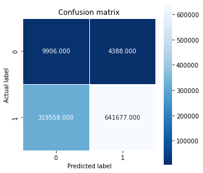

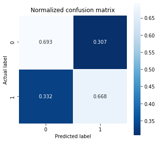

```python
cm_XGB_PCA_roc = confusion_matrix(ytest, predictions_roc_XGB_PCA)
cm_norm_XGB_PCA_roc = confusion_matrix(ytest, predictions_roc_XGB_PCA, normalize="true")

plt.figure(figsize=(5,5))
sns.heatmap(cm_XGB_PCA_roc, annot=True, fmt=".3f", linewidths=1, square = True, cmap = 'Blues_r');
plt.ylabel('Actual label');
plt.xlabel('Predicted label');
plt.title("Confusion matrix")

plt.figure(figsize=(5,5))
sns.heatmap(cm_norm_XGB_PCA_roc, annot=True, fmt=".3f", linewidths=1, square = True, cmap = 'Blues_r');
plt.ylabel('Actual label');
plt.xlabel('Predicted label');
plt.title("Normalized confusion matrix")
```

Analizando las matrices, y fijándonos en la que más información nos proporciona que es la normalizada, vemos que el modelo ha mejorado con respecto al XGBoost sin PCA en el ámbito de acierto de fallecidos, pero con una probabilidad de casi un 70% todavía nos seguimso quedando con el mejor modelo hasta ahora, el RandomForest. Veamos las métricas de nuestro modelo.

##### MÉTRICAS

```python
medidas(ytest, predictions_roc_XGB_PCA, predictions_proba_XGB_PCA)
```

|  | F1 | roc_score | accuracy | recall |
| --- | --- | --- | --- | --- |
| 0 | 0.798453 | 0.738175 | 0.667928 | 0.667555 |

Guardamos el modelo en formato pickle con el nombre de *XGB_PCA*.

```python
with open('../Models/XGB_PCA.pickle', 'wb') as f:
    pickle.dump(XGB_PCA, f)
```

##### CONCLUSIONES

En primer lugar, mostraremos los tiempos de ejecución.

```python
time_XGB = [start_XGB, final_XGB]
time_XGB_PCA = [start_XGB_PCA, final_XGB_PCA]
data_time_XGB = {"XGB": time_XGB, "XGB_PCA":time_XGB_PCA}
time_XGB = pd.DataFrame(data_time_XGB, columns=["XGB", "XGB_PCA"])
time_XGB.index=["start", "end"]
time_XGB = time_XGB.transpose()
time_XGB["total_time(s)"] = time_XGB["end"]-time_XGB["start"]
time_XGB
```

|  | start | end | total_time(s) |
| --- | --- | --- | --- |
| XGB | 1.639938e+09 | 1.639938e+09 | 373.620322 |
| XGB_PCA | 1.639938e+09 | 1.639939e+09 | 299.246597 |

Los tiempos de ejecución rondan los 6 minutos para el modelo XGboost y los 5 minutos para el modelo XGBoost con PCA. Como era de esperar, el tiempo de ejecución para PCA es mejor ya que introducimos un número reducido de variables. Además, hemos comprobado que el XGBoost con PCA nos proporciona mejores resultados, teniendo en cuenta nuestro objetivo, que el XGBoost. Luego, en este caso, merece la pena considerar el modelo de XGBoost con PCA.

Sin embargo, comparando el mejor modelo obtenido con el algoritmo de boosting XGBoost, no alcanzamos al modelo RandomForest que hemos mostrado antes. Luego, deberemos descartar el algoritmo XGBoost para nuestro problema.

## Light GBM

[figure not shown]

**Librerias a utilizar**

- Lightgbm as lgb
- Sklearn.metrics

### Light GBM sin PCA

**Variables a utilizar:**

- *X_train_oversampled*: Dataset de training con la técnica de oversampling sin la variable respuesta
- *y_train_oversampled*: Parte del training de la variable respuesta
- *x_test*: Dataset de testing modificado con la función de escalado

Haciendo uso de la función *modelos*, calculamos el tiempo inicial, final, la predicción normal y la probabilística y también el modelo entrenado, para así después, poder guardarlo en formato pickle.

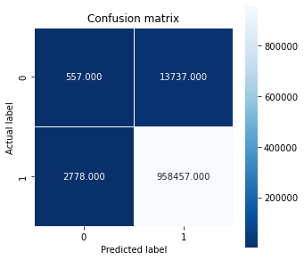

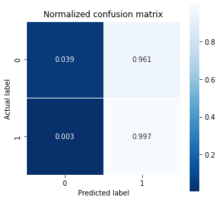

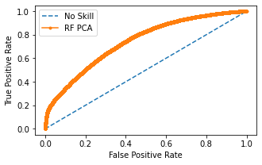

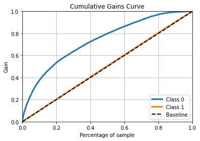

```python
start_LGBM, final_LGBM, prediction_LGBM, predictions_proba_LGBM, LGBM = modelos(X_train_oversampled, y_train_oversampled, x_test, lgb.LGBMClassifier(random_state=42), ytest)
```

Puesto que todavía estamos lejos de nuestro objetivo, planteamos el mismo modelo pero considerando el threshold óptimo que nos proporciona la curva de ROC.

##### THRESHOLD ÓPTIMO MEDIANTE LA CURVA DE ROC

```python
yhat_LGBM = predictions_proba_LGBM[:, 1]
fpr_LGBM, tpr_LGBM, thresholds_LGBM = roc_curve(ytest, yhat_LGBM)
```

Ahora, generamos las nuevas predicciones teniendo en cuenta nuestro nuevo threshols.

```
Best Threshold=0.928104, F-Score=0.670
```

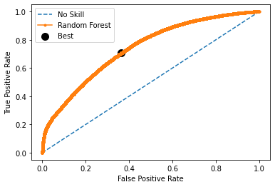

```python
gmeans_LGBM = np.sqrt(tpr_LGBM * (1-fpr_LGBM))
ix_LGBM = np.argmax(np.sqrt(tpr_LGBM * (1-fpr_LGBM)))
predictions_roc_LGBM=(predictions_proba_LGBM[:,1] >= thresholds_LGBM[ix_LGBM]).astype(int)
print('Best Threshold=%f, F-Score=%.3f' % (thresholds_LGBM[ix_LGBM], gmeans_LGBM[ix_LGBM]))

plt.plot([0,1], [0,1], linestyle='--', label='No Skill')
plt.plot(fpr_LGBM, tpr_LGBM, marker='.', label='Random Forest')
plt.scatter(fpr_LGBM[ix_LGBM], tpr_LGBM[ix_LGBM], s=100, marker='o', color='black', label='Best')
# axis labels
plt.xlabel('False Positive Rate')
plt.ylabel('True Positive Rate')
plt.legend()
# show the plot
plt.show()
```

El threshold obtenido, como se puede comprobar, es de 0.93.

Repetimos las matrices de confusión considerando el nuevo vector de predicciones obtenido mediante el threshold óptimo:

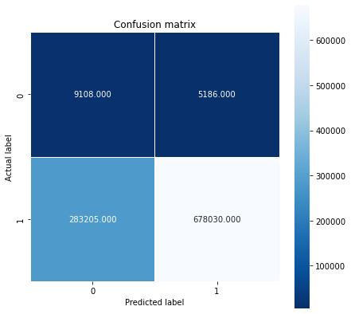

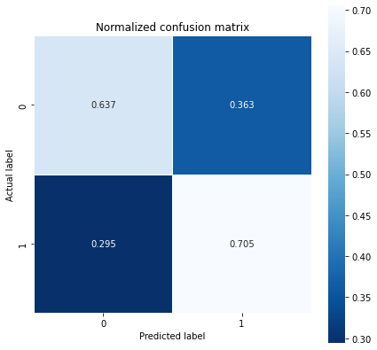

```python
cm_LGBM_roc = confusion_matrix(ytest, predictions_roc_LGBM)
cm_norm_LGBM_roc = confusion_matrix(ytest, predictions_roc_LGBM, normalize="true")

plt.figure(figsize=(5,5))
sns.heatmap(cm_LGBM_roc, annot=True, fmt=".3f", linewidths=1, square = True, cmap = 'Blues_r');
plt.ylabel('Actual label');
plt.xlabel('Predicted label');
plt.title("Confusion matrix")

plt.figure(figsize=(5,5))
sns.heatmap(cm_norm_LGBM_roc, annot=True, fmt=".3f", linewidths=1, square = True, cmap = 'Blues_r');
plt.ylabel('Actual label');
plt.xlabel('Predicted label');
plt.title("Normalized confusion matrix")
```

La mejoría es notable en las matrices de confusión, como se puede apreciar, pero, al igual que con el algoritmo XGBoost, todavía falla mucho en los individuos de la clase 0, comprobemos las métricas para verlo numéricamente.

##### MÉTRICAS

```python
medidas(ytest, predictions_roc_LGBM, predictions_proba_LGBM)
```

|  | F1 | roc_score | accuracy | recall |
| --- | --- | --- | --- | --- |
| 0 | 0.824628 | 0.741354 | 0.704375 | 0.705374 |

Parece que nuestras sospechas eran ciertas puesto que el recall y el roc_score no son valores muy elevados.

Ahora, guardamos el modelo en un formato pickle con el nombre *LGBM*

```python
with open('../Models/LGBM.pickle', 'wb') as f:
    pickle.dump(LGBM, f)
```

### Light GBM con PCA

**Variables a utilizar:**

- *X_train_pca_2*: Dataset de training obtenido con la técnica de selección de variables PCA
- *y_train_oversampled*: Parte del training de la variable respuesta
- *X_test_pca_2*: Dataset de testing obtenido con la técnica de seleccioón de variables PCA

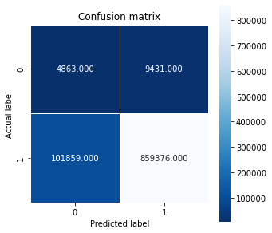

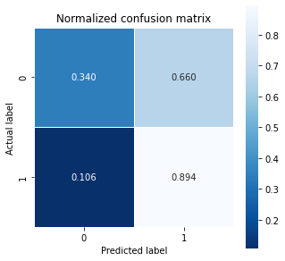

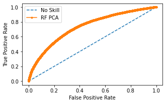

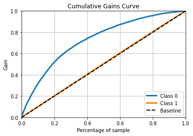

```python
start_LGBM_PCA, final_LGBM_PCA, prediction_LGBM_PCA, predictions_proba_LGBM_PCA, LGBM_PCA = modelos(X_train_pca_2, y_train_oversampled, X_test_pca_2, lgb.LGBMClassifier(random_state=42), ytest)
```

Como podemos observar, la matriz de confusión del modelo no es nada buena. Para tener otra visión del modelo, calcularemos el threshol óptimo mediante la curva de ROC. Esto permitirá que el umbral en el que se decide que la predicción es fallecido o no fallecido cambie, y, por tanto, la matriz de confusión cambiará.

##### THRESHOLD ÓPTIMO MEDIANTE LA CURVA DE ROC

```python
yhat_LGBM_PCA = predictions_proba_LGBM_PCA[:, 1]
fpr_LGBM_PCA, tpr_LGBM_PCA, thresholds_LGBM_PCA = roc_curve(ytest, yhat_LGBM_PCA)
```

```
Best Threshold=0.703699, F-Score=0.678
```

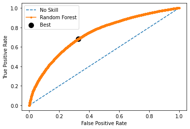

```python
gmeans_LGBM_PCA = np.sqrt(tpr_LGBM_PCA * (1-fpr_LGBM_PCA))
ix_LGBM_PCA = np.argmax(np.sqrt(tpr_LGBM_PCA * (1-fpr_LGBM_PCA)))
predictions_roc_LGBM_PCA=(predictions_proba_LGBM_PCA[:,1] >= thresholds_LGBM_PCA[ix_LGBM_PCA]).astype(int)
print('Best Threshold=%f, F-Score=%.3f' % (thresholds_LGBM_PCA[ix_LGBM_PCA], gmeans_LGBM_PCA[ix_LGBM_PCA]))

plt.plot([0,1], [0,1], linestyle='--', label='No Skill')
plt.plot(fpr_LGBM_PCA, tpr_LGBM_PCA, marker='.', label='Random Forest')
plt.scatter(fpr_LGBM_PCA[ix_LGBM_PCA], tpr_LGBM_PCA[ix_LGBM_PCA], s=100, marker='o', color='black', label='Best')
# axis labels
plt.xlabel('False Positive Rate')
plt.ylabel('True Positive Rate')
plt.legend()
# show the plot
plt.show()
```

Una vez tenemos el vector de predicciones con la curva ROC, mostramos nuevamente la matriz de confusión.

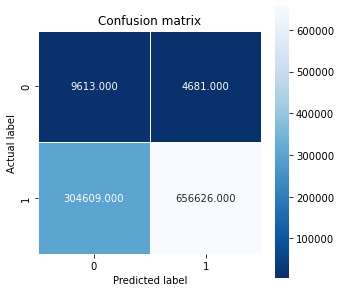

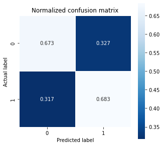

```python
cm_LGBM_PCA_roc = confusion_matrix(ytest, predictions_roc_LGBM_PCA)
cm_norm_LGBM_PCA_roc = confusion_matrix(ytest, predictions_roc_LGBM_PCA, normalize="true")

plt.figure(figsize=(5,5))
sns.heatmap(cm_LGBM_PCA_roc, annot=True, fmt=".3f", linewidths=1, square = True, cmap = 'Blues_r');
plt.ylabel('Actual label');
plt.xlabel('Predicted label');
plt.title("Confusion matrix")

plt.figure(figsize=(5,5))
sns.heatmap(cm_norm_LGBM_PCA_roc, annot=True, fmt=".3f", linewidths=1, square = True, cmap = 'Blues_r');
plt.ylabel('Actual label');
plt.xlabel('Predicted label');
plt.title("Normalized confusion matrix")
```

Claramente las matrices cambian y, el rendimiento del modelo no es malo del todo. Veamos ahora las métricas del modelo mediante la función *medidas*.

##### MÉTRICAS

```python
medidas(ytest, predictions_roc_LGBM_PCA, predictions_proba_LGBM_PCA)
```

|  | F1 | roc_score | accuracy | recall |
| --- | --- | --- | --- | --- |
| 0 | 0.809379 | 0.734423 | 0.682952 | 0.683107 |

Ahora, guardamos el modelo en un formato pickle con el nombre *LGBM_PCA*

```python
with open('../Models/LGBM_PCA.pickle', 'wb') as f:
    pickle.dump(LGBM_PCA, f)
```

##### CONCLUSIONES

Los tiempos de ejecución se muestran a continuación.

```python
time_LGBM = [start_LGBM, final_LGBM]
time_LGBM_PCA = [start_LGBM_PCA, final_LGBM_PCA]
data_time_LGBM = {"LGBM": time_LGBM, "LGBM_PCA":time_LGBM_PCA}
time_LGBM = pd.DataFrame(data_time_LGBM, columns=["LGBM", "LGBM_PCA"])
time_LGBM.index=["start", "end"]
time_LGBM = time_LGBM.transpose()
time_LGBM["total_time(s)"] = time_LGBM["end"]-time_LGBM["start"]
time_LGBM
```

|  | start | end | total_time(s) |
| --- | --- | --- | --- |
| LGBM | 1.639938e+09 | 1.639938e+09 | 24.196781 |
| LGBM_PCA | 1.639938e+09 | 1.639938e+09 | 13.555180 |

# Mejor modelo con modificación de hiperparámetros

Después de haber analizado todos los modelos, hemos podido comprobar que el mejor es el RandomForest debido a su gran rendimiento en la matriz de confusión normalizada.

Ahora, lo que deberemos hacer será tomar el modelo RandomForest e intentar encontrar sus hiperparámetros óptimos. Para ello, lo que se debe hacer es tomar diferentes hiperparámetros e iterar. Crear un modelo para cada uno de estos hiperparámetros que definamos y, después determinar cual es el mejor de todos los modelos.

Para ello, definimos un pipeline con el modelo de RandomForest.

```python
RandF = Pipeline(steps=[('classifier', RandomForestClassifier(random_state=42))])
```

Mediante el atributo .get_params() podemos obtener todos los hiperparámetros que tiene el RandomForest.

```python
RandF.get_params().keys()
```

```
dict_keys(['memory', 'steps', 'verbose', 'classifier', 'classifier__bootstrap', 'classifier__ccp_alpha', 'classifier__class_weight', 'classifier__criterion', 'classifier__max_depth', 'classifier__max_features', 'classifier__max_leaf_nodes', 'classifier__max_samples', 'classifier__min_impurity_decrea…
```

En nuestro caso, la optimización de hiperparámetros la haremos con la función RandomizedSearCV. Realizar todas las combinaciones de hiperparámetros requiere un alto coste computacional ya que estaríamos aplicando lo conocido como *fuerza bruta*. Por ello, el algoritmo RandomizedSearchCV consiste en muestrear al azar a partir de una variedad de parámetros. De esta forma, este algoritmo no prueba todas las combinaciones posibles de valores sino que sólamente un número de ellas.

```python
param_grid = {
    'classifier__n_estimators': [20, 50, 100],
    #'classifier__class_weight': [{0:5.1, 1:0.05}, {0:6.1, 1:0.05}, {0:7.1, 1:0.05}],
    'classifier__max_depth' : [6,8,10],
    'classifier__criterion' :["gini", "entropy"]}

start_hiperparam=time.time()

from sklearn.model_selection import RandomizedSearchCV

CV = RandomizedSearchCV(RandF, param_grid, cv=10, random_state=42, n_jobs=2, scoring="recall")

BM = CV.fit(X_train_oversampled, y_train_oversampled)
print(CV.best_params_)
print(CV.best_score_)

end_hiperparam = time.time()
```

```
{'classifier__n_estimators': 100, 'classifier__max_depth': 10, 'classifier__criterion': 'gini'}
0.9381786958439158
```

```python
prediction_BM = CV.predict(x_test)
```

```python
print("Classification Report")
print(classification_report(ytest, prediction_Best_model))
```

```
Classification Report
              precision    recall  f1-score   support

           0       0.07      0.32      0.11     14294
           1       0.99      0.94      0.96    961235

    accuracy                           0.93    975529
   macro avg       0.53      0.63      0.54    975529
weighted avg       0.98      0.93      0.95    975529
```

```python
predictions_proba_BM = CV.predict_proba(x_test)
```

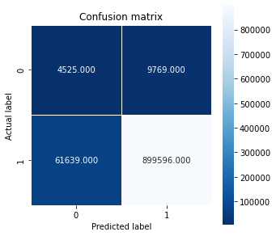

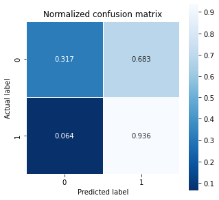

```python
cm_Best_model = confusion_matrix(ytest, prediction_Best_model)
cm_norm_Best_model = confusion_matrix(ytest, prediction_Best_model, normalize="true")

plt.figure(figsize=(5,5))
sns.heatmap(cm_Best_model, annot=True, fmt=".3f", linewidths=1, square = True, cmap = 'Blues_r');
plt.ylabel('Actual label');
plt.xlabel('Predicted label');
plt.title("Confusion matrix")

plt.figure(figsize=(5,5))
sns.heatmap(cm_norm_Best_model, annot=True, fmt=".3f", linewidths=1, square = True, cmap = 'Blues_r');
plt.ylabel('Actual label');
plt.xlabel('Predicted label');
plt.title("Normalized confusion matrix")
```

```python
yhat_BM = predictions_proba_BM[:, 1]
fpr_BM, tpr_BM, thresholds_BM = roc_curve(ytest, yhat_BM)
```

```
Best Threshold=0.752012, F-Score=0.696
```

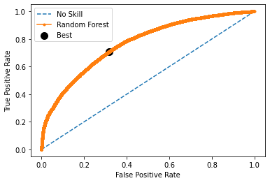

```python
gmeans_BM = np.sqrt(tpr_BM * (1-fpr_BM))
ix_BM = np.argmax(np.sqrt(tpr_BM * (1-fpr_BM)))
predictions_roc_BM=(predictions_proba_BM[:,1] >= thresholds_BM[ix_BM]).astype(int)
print('Best Threshold=%f, F-Score=%.3f' % (thresholds_BM[ix_BM], gmeans_BM[ix_BM]))

plt.plot([0,1], [0,1], linestyle='--', label='No Skill')
plt.plot(fpr_BM, tpr_BM, marker='.', label='Random Forest')
plt.scatter(fpr_BM[ix_BM], tpr_BM[ix_BM], s=100, marker='o', color='black', label='Best')
# axis labels
plt.xlabel('False Positive Rate')
plt.ylabel('True Positive Rate')
plt.legend()
# show the plot
plt.show()
```

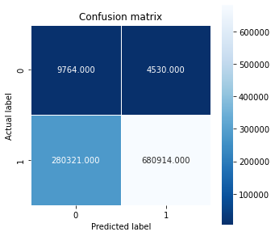

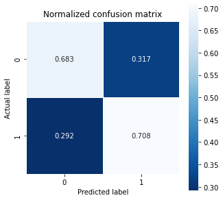

```python
cm_Best_model_roc = confusion_matrix(ytest, predictions_roc_BM)
cm_norm_Best_model_roc = confusion_matrix(ytest, predictions_roc_BM, normalize="true")

plt.figure(figsize=(5,5))
sns.heatmap(cm_Best_model_roc, annot=True, fmt=".3f", linewidths=1, square = True, cmap = 'Blues_r');
plt.ylabel('Actual label');
plt.xlabel('Predicted label');
plt.title("Confusion matrix")

plt.figure(figsize=(5,5))
sns.heatmap(cm_norm_Best_model_roc, annot=True, fmt=".3f", linewidths=1, square = True, cmap = 'Blues_r');
plt.ylabel('Actual label');
plt.xlabel('Predicted label');
plt.title("Normalized confusion matrix")
```

Podemos comprobar, que aunque la optimización de hiperparámetros nos diga que es el mejor modelo que hemos encontrado, no es del todo cierto. Las mtrices de confusión que hemos obtenido para el modelo RF son bastante mejores. Luego, parece, que en nuestro caso la optimización de hiperparámetros no ha dado sus frutos y nos tenemos que quedar con el modelo RF que hemos definido anteriormente.

```python
with open('../Models/BM.pickle', 'wb') as f:
    pickle.dump(BM, f)
```